# ad hoc methods for detecting population trends

David Nguyen

2020-08-14

# Trend detection: sequential vs fixed sample approaches

Wildlife managers and conservationists need to detect population trends in a timely and reliable manner. Timeliness is reflected in the number of samples (e.g., years) needed to detect a trend. Reliability is captured by the type I error and power of a test. Simple linear regression using sampling time as a covariate is commonly used to detect population trends. Researchers have used this approach to identify the minimum years of monitoring needed to detect population trends.

For example, [White (2019)](https://academic.oup.com/bioscience/article/69/1/40/5195956#129750432) repeatedly fit linear models to sub-samples of a time series to identify the minimum sample size needed to achieve a specified type I error and power. That is, for a time series with $T$ time points, he fit a linear regression model to each contiguous sub-samples of size $2, 3, \ldots, T-1$. Using the arbitrary (but conventional) benchmark of 0.8 power at the 0.05 significance level, White used the regression outputs to find the minimum sub-sample length such that 80 % of the samples had a significant regression slope coefficient. This is essentially a sample size calculation for a one-sided hypothesis test with $H_0: r = 0$ and $H_1: r > 0$ or $H_1: r < 0$.

White used data simulated from the following population model for examples of how to calculate fixed-sample sizes needed to detect population trends,
$$N_{t+1} \sim N(N_t + r,\sigma),$$
Where $N_t$ is the population size at time $t$, $r$ is the population trend, and $\sigma$ is the population variability.

We can also test this one-sided hypothesis using a sequential test. We can define our sequential test statistic at time $t$ $(S_t)$ as:

$$\begin{align*}
S_t &= \Sigma^{t}_{i=1}R_i & \text{for } t &= 1,2,3, \ldots\\
\text{and } R_1 &= 0 & R_t &= \log \left( \frac{P(N_{t} | N_{t-1}, \hat{r}_t, \sigma)}{P(N_{t} | N_{t-1}, r = 0, \sigma)} \right)
\end{align*}$$

$\hat{r}_t$ is the MLE of r computed from data points $X_1,\ldots,X_t$. The MLE is constrained to $(0,\inf)$ or $(-\inf, 0)$ depending on whether detection of a linear increase or decrease is desired. (In my computer implementation, I just use a finite interval for the constrained MLE).

The decision rule is:

$$\begin{align*}
\begin{cases}
\text{reject } H_0 & S_t > \log(A) \\
\text{accept } H_0 & S_t \leq \log(B) \\
\text{continue sampling} & \log(B) < S_t \leq \log(A)
\end{cases}
\end{align*}$$

The thresholds are set following Wald’s method such that $A \sim \frac{1-\beta}{\alpha}$ and $B \sim \frac{\beta}{1-\alpha}$ where $\alpha$ and $\beta$ is the probabilities of type I and II error, respectively (I’m not sure if these approximations work for this inference problem, I still need to check if these boundaries give the correct error probabilities).

For the situation where $\sigma$ is unknown, the sequential test statistic is instead calculated using the current ML estimate of of the standard deviation ($\hat{\sigma_t}$). $\hat{\sigma_t}$ is computed as a [running variance](https://www.johndcook.com/blog/standard_deviation/) from the first differences of the observations $N_t - N_{t-1} \overset{iid}{\sim} Norm(r,\sigma)$ for $t = 2,3,4,\ldots$. If we know that there is a lower bound on the variability of the population when it is stable we can use $\sigma_{t} = max \left( \sigma_{mle},\sigma_{min} \right)$.

# Comparison of detection times

Tests:

1. fixed-sample size linear regression test
2. sequential test ($\sigma$ known)
3. sequential test ($\sigma$ unknown)
   - the running MLE estimate of $\sigma$ is used to calculate the test statistic
   - note that the MLE estimate of $\sigma$ is uncorrected (biased low)

I compare the performance of the tests according to the time required to reject the null hypothesis that there is no population trend ($\alpha = 0.05, \beta=0.2$). The population data were simulated from an additive model $N_{t+1} = N(N_t + r,\sigma)$ with parameters $r =$ 1.5 and $\sigma =$ 5. The population was initialized as 1000 individuals and was run for 100 time steps. 100 simulations were used.

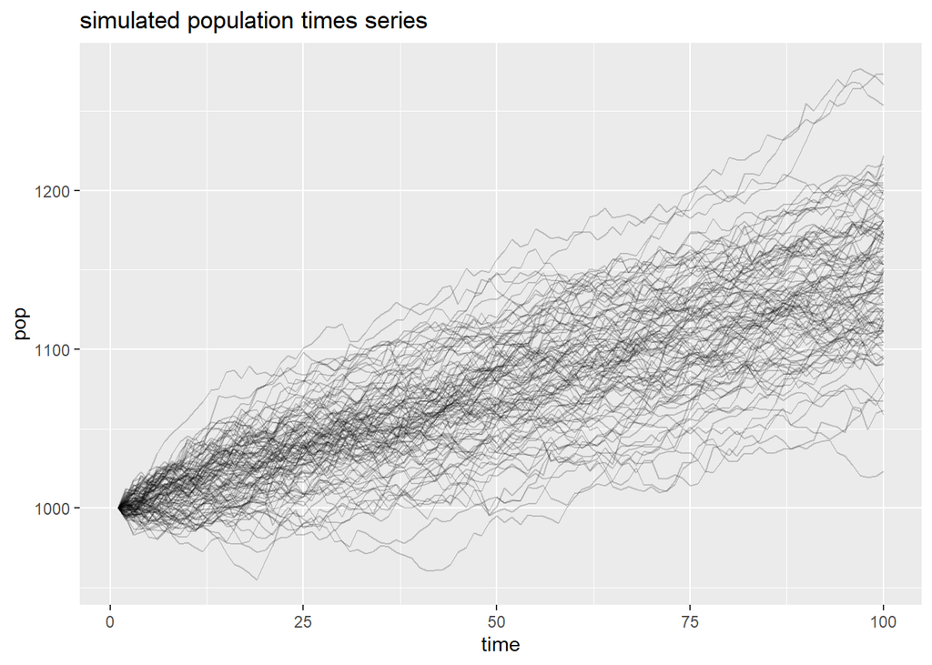

| method | delay >= samplesize | n |
| --- | --- | --- |
| delay_est | FALSE | 96 |
| delay_est | TRUE | 4 |
| delay_known | FALSE | 92 |
| delay_known | TRUE | 8 |

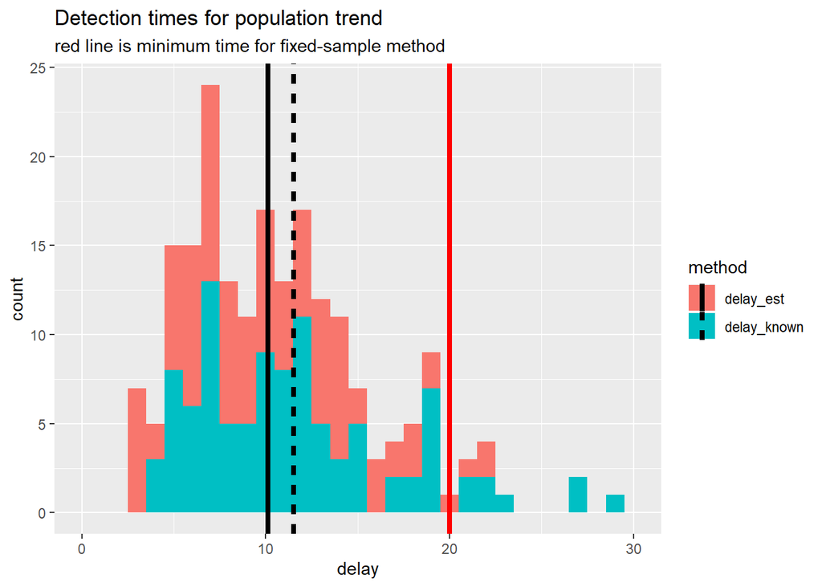

Note, the probability models used for the fixed-sample and sequential tests are not the same. The sequential test uses the true data-generating model (variability is from process noise) whereas the fixed-sample test fits a simple linear regression using time as a covariate (observation noise). A more comparable test would be to use a sequential t-test on the first-differenced values of the population sizes.

# Performance when null is true (no trend)

How do the tests perform when there is no trend? The sequential tests would (ideally) accept the null hypothesis. The fixed-sample procedure cannot accept the null, so I will consider any non-significant p-values to indicate that the null was “accepted.”

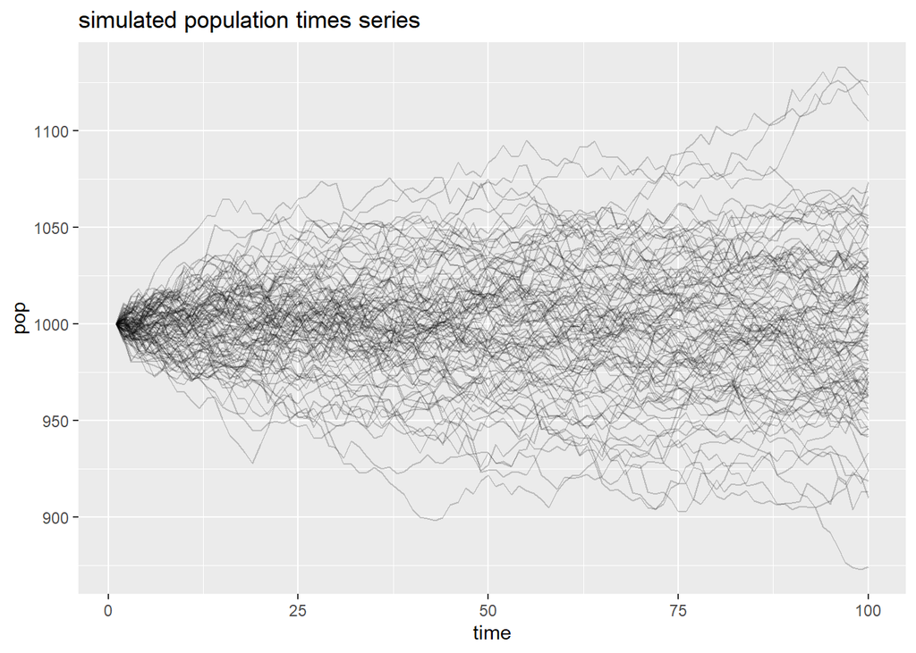

I don’t like the behavior of this model when there is no trend. The distribution isn’t stationary so I don’t think this is a fair test. This is a gaussian random walk which is distributed at the n<sup>th</sup> time point as $N(0,n\sigma)$. That is, the variance is unbounded as $n \rightarrow \inf$.

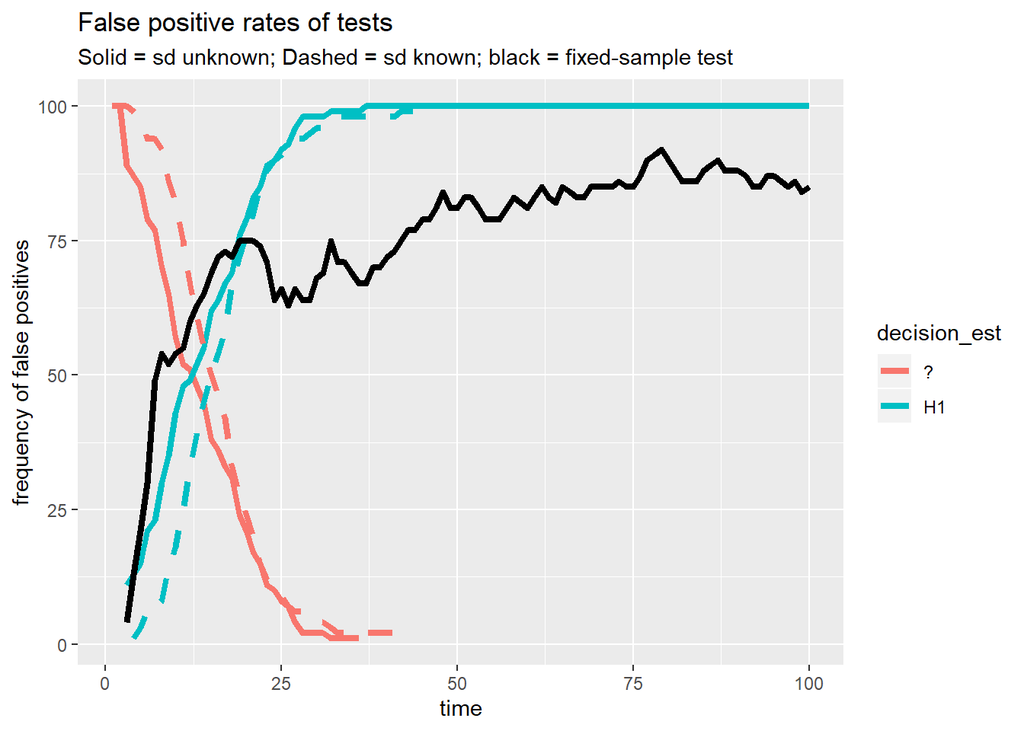

All of the tests perform quite poorly. But, I think that this is more an issue with the null model. It would be better to simulate from a gompertz model at (stochastic) equilibrium to generate test data.

# Performance on Gompertz model

The Gompertz model is commonly used to model population dynamics.

$$\begin{align*}
X_{t+1} &= \lambda + b (X_t) + N(0, \sigma^2)
\end{align*}$$

$X_t$ is the log population size at time $t$, $\lambda$ is the population growth rate per time step, and $b$ is the magnitude of density-dependence. The 100 simulations presented below were run for 100 time steps with an intial population size of $\ln(1000)$, $\lambda = 2.4$, $b = 0.65$, and $\sigma = 0.4$

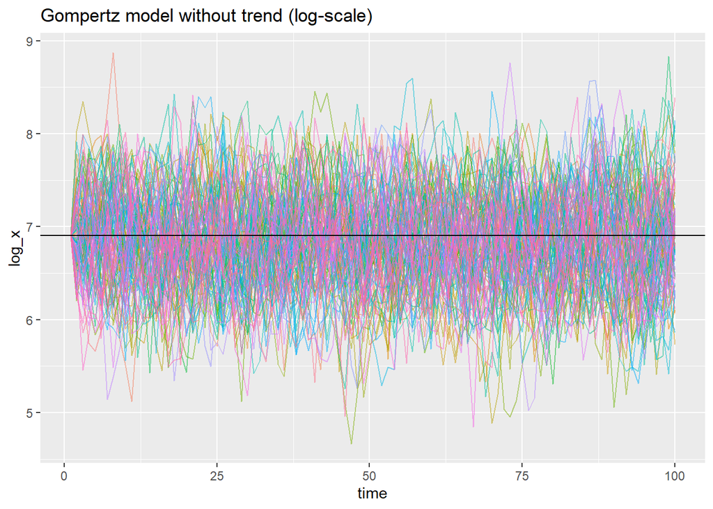

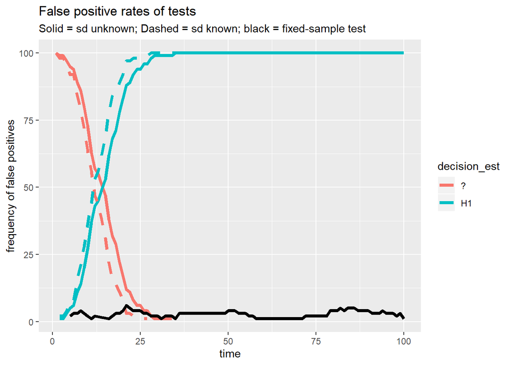

Again, the sequential tests all eventually reject the null in favor of the hypothesis that the population is growing. But the fixed-sample test actuallly performs very well. I’m not sure why the sequential test are so bad. Note that I am using a one-sided alternative for the sequential tests here ($H_1: r > 0$) but I don’t think that would account for the poor performance.

Maybe is an issue with the likelihood model? Or th decision boundaries?

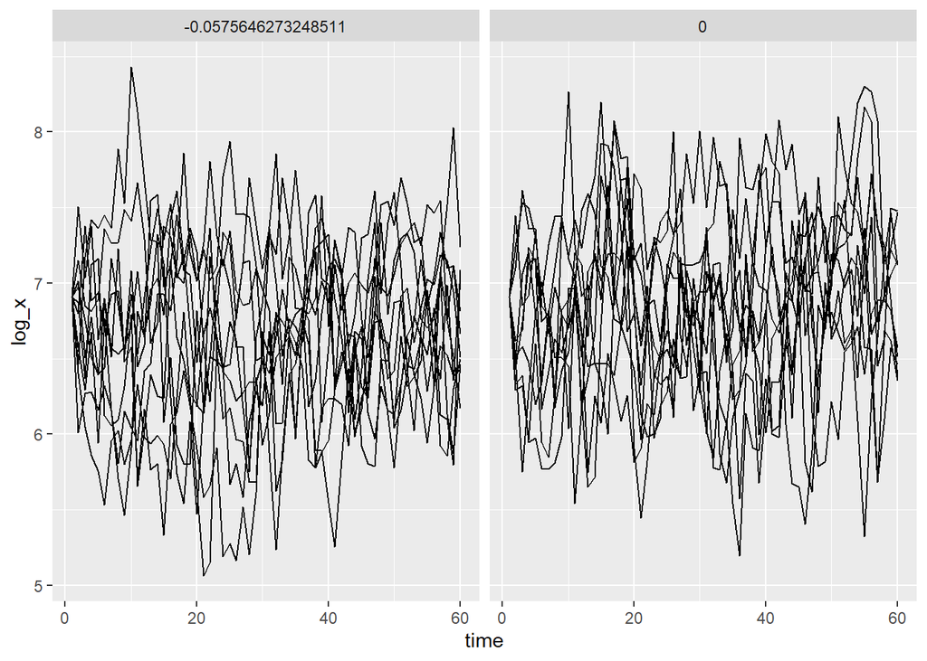

# to-dos

- test performance on time-series with no trend (should be stationary dist’n; include burn-in time)
- simulation studies using different trends and sd